# TCGA-BRCA multi-omics: data preparation and train/test split

RNA-seq, DNA methylation (450k) and protein (RPPA) with clinical data

Group 2: Multiomics - Parniyan, Sergi, Baizhen, Paula, Yueling

12 November 2026

# 1 Overview

This report documents the preparation of the **TCGA breast invasive carcinoma (BRCA)** multi-omics data used in the project. It runs the same steps as `01_data_preprocess/01_data_preparation.R`. Three omics layers are combined with the clinical data:

- **RNA-seq**: RSEM gene-level counts (`RNASeq2Gene`), normalised to `log2(CPM + 1)`.
- **DNA methylation**: Illumina 450k array, beta values (`Methylation_methyl450`).
- **Protein**: reverse-phase protein array (`RPPAArray`).

**Steps:**

1. Download the data with `curatedTCGAData` (version 2.1.1).
2. Keep primary tumour samples from patients with data in all three omics.
3. Normalise the RNA-seq counts to `log2(CPM + 1)` (no features are filtered).
4. Harmonise sample and patient identifiers across datasets.
5. Select female patients with a known pathological stage and define a three-level stage outcome.
6. Split patients into a **training set (70%)** and a **test set (30%)**, with the same split in every dataset.
7. Save (or compare with the saved) `.rds` files in `data/data_split/`.

**General principle:** every dataset contains **the same patients in the same order**, and the split is done at **patient level** and **before any data-driven preprocessing** (filtering, imputation, scaling). Every later QC decision is made on the training set only and then applied to the test set. The only transformation applied here, `log2(CPM + 1)`, is computed sample by sample and therefore does not share information between training and test.

# 2 Data download

## 2.1 Available assays

With `dry.run = TRUE` the function only lists the assays available for BRCA, without downloading anything.

```r
curatedTCGAData(diseaseCode = "BRCA", assays = "*",
                version = "2.1.1", dry.run = TRUE)
```

| ah_id | title | file_size | rdataclass | rdatadateadded | rdatadateremoved |
| --- | --- | --- | --- | --- | --- |
| EH4769 | BRCA_CNASeq-20160128 | 0 Mb | RaggedExperiment | 2021-01-27 | NA |
| EH4770 | BRCA_CNASNP-20160128 | 9.8 Mb | RaggedExperiment | 2021-01-27 | NA |
| EH4771 | BRCA_CNVSNP-20160128 | 2.8 Mb | RaggedExperiment | 2021-01-27 | NA |
| EH4773 | BRCA_GISTIC_AllByGene-20160128 | 1.2 Mb | SummarizedExperiment | 2021-01-27 | NA |
| EH4774 | BRCA_GISTIC_Peaks-20160128 | 0 Mb | RangedSummarizedExperiment | 2021-01-27 | NA |
| EH4775 | BRCA_GISTIC_ThresholdedByGene-20160128 | 0.3 Mb | SummarizedExperiment | 2021-01-27 | NA |
| EH4777 | BRCA_Methylation_methyl27-20160128_assays | 60.7 Mb | SummarizedExperiment | 2021-01-27 | NA |
| EH4778 | BRCA_Methylation_methyl27-20160128_se | 0.4 Mb | SummarizedExperiment | 2021-01-27 | NA |
| EH4779 | BRCA_Methylation_methyl450-20160128_assays | 2646.4 Mb | RaggedExperiment | 2021-01-27 | NA |
| EH4780 | BRCA_Methylation_methyl450-20160128_se | 6 Mb | SummarizedExperiment | 2021-01-27 | NA |
| EH4782 | BRCA_mRNAArray-20160128 | 27.3 Mb | SummarizedExperiment | 2021-01-27 | NA |
| EH4783 | BRCA_Mutation-20160128 | 4.5 Mb | SummarizedExperiment | 2021-01-27 | NA |
| EH4784 | BRCA_RNASeq2Gene-20160128 | 43.1 Mb | DFrame | 2021-01-27 | NA |
| EH4786 | BRCA_RNASeqGene-20160128 | 30 Mb | SummarizedExperiment | 2021-01-27 | NA |
| EH4787 | BRCA_RPPAArray-20160128 | 1.5 Mb | SummarizedExperiment | 2021-01-27 | NA |
| EH8124 | BRCA_miRNASeqGene-20160128 | 2 Mb | SummarizedExperiment | 2023-04-24 | NA |
| EH8125 | BRCA_RNASeq2GeneNorm-20160128 | 93.6 Mb | SummarizedExperiment | 2023-04-24 | NA |

## 2.2 Selected assays

| Assay | Content |
| --- | --- |
| `RNASeq2Gene` | RSEM gene-level counts (raw, non-negative) |
| `Methylation_methyl450` | DNA methylation, Illumina 450k array (beta values, 0–1) |
| `RPPAArray` | Protein expression, reverse-phase protein array (log2, median-centred) |

The result is a `MultiAssayExperiment` object; the clinical data are in `colData()`. Downloads are cached by ExperimentHub, so later runs are fast.

```r
brca <- curatedTCGAData(
  diseaseCode = "BRCA",
  assays      = c("RNASeq2Gene", "Methylation_methyl450", "RPPAArray"),
  version     = "2.1.1",
  dry.run     = FALSE
)

brca
```

```
## A MultiAssayExperiment object of 3 listed
##  experiments with user-defined names and respective classes.
##  Containing an ExperimentList class object of length 3:
##  [1] BRCA_RNASeq2Gene-20160128: SummarizedExperiment with 20501 rows and 1212 columns
##  [2] BRCA_RPPAArray-20160128: SummarizedExperiment with 226 rows and 937 columns
##  [3] BRCA_Methylation_methyl450-20160128: SummarizedExperiment with 485577 rows and 885 columns
## Functionality:
##  experiments() - obtain the ExperimentList instance
##  colData() - the primary/phenotype DataFrame
##  sampleMap() - the sample coordination DataFrame
##  `$`, `[`, `[[` - extract colData columns, subset, or experiment
##  *Format() - convert into a long or wide DataFrame
##  assays() - convert ExperimentList to a SimpleList of matrices
##  exportClass() - save data to flat files
```

```r
names(experiments(brca))   # exact assay names used below
```

```
## [1] "BRCA_RNASeq2Gene-20160128"           "BRCA_RPPAArray-20160128"             "BRCA_Methylation_methyl450-20160128"
```

```r
flow <- add_step(flow, "Downloaded (patients in colData)", nrow(colData(brca)))
```

# 3 Sample selection

## 3.1 Primary tumours with all three omics

`TCGAprimaryTumors()` uses the sample type code in the TCGA barcode (e.g. `TCGA-A1-A0SB-01A-...`): it keeps `01` = primary solid tumour and removes `06` = metastatic, `11` = solid tissue normal, etc. `intersectColumns()` keeps only patients with data in all three omics.

```r
brca <- TCGAprimaryTumors(brca)
brca <- intersectColumns(brca)

lengths(colnames(brca))    # samples per assay (should be equal)
```

```
##           BRCA_RNASeq2Gene-20160128             BRCA_RPPAArray-20160128 BRCA_Methylation_methyl450-20160128
##                                 635                                 635                                 635
```

```r
flow <- add_step(flow, "Primary tumour, all three omics", nrow(colData(brca)))
```

# 4 Omics and clinical data

Each omics matrix has features in rows and samples in columns. The methylation assay is stored on disk (HDF5) and is converted to an in-memory matrix (~485,000 probes), which takes some time and memory.

```r
counts <- assay(brca[["BRCA_RNASeq2Gene-20160128"]])
meth   <- as.matrix(assay(brca[["BRCA_Methylation_methyl450-20160128"]]))  # HDF5 -> in-memory matrix
prot   <- assay(brca[["BRCA_RPPAArray-20160128"]])
clin   <- as.data.frame(colData(brca))                                     # one row per patient

data.frame(dataset = c("RNA-seq counts", "Methylation", "Protein", "Clinical"),
           rows    = c(nrow(counts), nrow(meth), nrow(prot), nrow(clin)),
           columns = c(ncol(counts), ncol(meth), ncol(prot), ncol(clin)),
           content = c("genes x samples", "CpG probes x samples",
                       "proteins x samples", "patients x variables"))
```

| dataset | rows | columns | content |
| --- | --- | --- | --- |
| RNA-seq counts | 20501 | 635 | genes x samples |
| Methylation | 485577 | 635 | CpG probes x samples |
| Protein | 226 | 635 | proteins x samples |
| Clinical | 635 | 2684 | patients x variables |

## 4.1 RNA-seq: counts to log2(CPM + 1)

Raw counts should be non-negative and without missing values. RSEM expected counts can contain some non-integer values, which is expected.

```r
data.frame(check = c("Minimum value", "Maximum value", "Negative values",
                     "Missing values", "Proportion of integer values"),
           value = c(min(counts, na.rm = TRUE), max(counts, na.rm = TRUE),
                     sum(counts < 0, na.rm = TRUE), sum(is.na(counts)),
                     round(mean(counts == round(counts), na.rm = TRUE), 3)))
```

| check | value |
| --- | --- |
| Minimum value | 0.000 |
| Maximum value | 6276990.000 |
| Negative values | 0.000 |
| Missing values | 0.000 |
| Proportion of integer values | 0.915 |

```r
lib_size <- colSums(counts)                          # total counts per sample
rna      <- log2(t(t(counts) / lib_size * 1e6) + 1)  # log2(CPM + 1), genes x samples
rm(counts); invisible(gc())

data.frame(check = c("Minimum value", "Maximum value", "Negative values",
                     "Missing values", "Genes", "Samples"),
           value = c(round(min(rna), 2), round(max(rna), 2), sum(rna < 0),
                     sum(is.na(rna)), nrow(rna), ncol(rna)))
```

| check | value |
| --- | --- |
| Minimum value | 0.00 |
| Maximum value | 16.57 |
| Negative values | 0.00 |
| Missing values | 0.00 |
| Genes | 20501.00 |
| Samples | 635.00 |

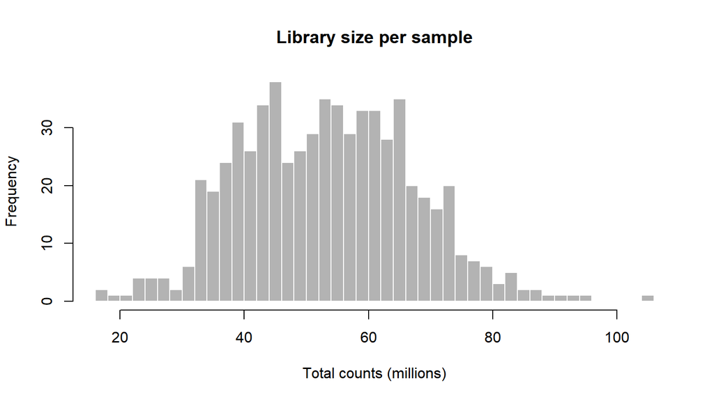

```r
hist(lib_size / 1e6, breaks = 40, col = "grey70", border = "white",
     main = "Library size per sample", xlab = "Total counts (millions)")
```

The `sampleMap` links each omics sample (full barcode) to its patient.

```r
smap <- as.data.frame(sampleMap(brca))
head(smap)
```

| assay | primary | colname |
| --- | --- | --- |
| BRCA_RNASeq2Gene-20160128 | TCGA-A1-A0SF | TCGA-A1-A0SF-01A-11R-A144-07 |
| BRCA_RNASeq2Gene-20160128 | TCGA-A1-A0SH | TCGA-A1-A0SH-01A-11R-A084-07 |
| BRCA_RNASeq2Gene-20160128 | TCGA-A1-A0SJ | TCGA-A1-A0SJ-01A-11R-A084-07 |
| BRCA_RNASeq2Gene-20160128 | TCGA-A1-A0SK | TCGA-A1-A0SK-01A-12R-A084-07 |
| BRCA_RNASeq2Gene-20160128 | TCGA-A1-A0SO | TCGA-A1-A0SO-01A-22R-A084-07 |
| BRCA_RNASeq2Gene-20160128 | TCGA-A1-A0SQ | TCGA-A1-A0SQ-01A-21R-A144-07 |

# 5 Identifier harmonisation

## 5.1 Barcodes to patient IDs

The omics matrices use full sample barcodes (e.g. `TCGA-A1-A0SB-01A-11R-A144-07`), while the clinical data use patient IDs (`TCGA-A1-A0SB`). `TCGAbarcode()` trims the barcodes to the first 12 characters.

```r
colnames(rna)  <- TCGAbarcode(colnames(rna))
colnames(meth) <- TCGAbarcode(colnames(meth))
colnames(prot) <- TCGAbarcode(colnames(prot))
```

## 5.2 Duplicated patients

If a patient had more than one aliquot of the same tumour, only the first is kept.

```r
data.frame(dataset    = c("RNA-seq", "Methylation", "Protein"),
           duplicated = c(sum(duplicated(colnames(rna))),
                          sum(duplicated(colnames(meth))),
                          sum(duplicated(colnames(prot)))))
```

| dataset | duplicated |
| --- | --- |
| RNA-seq | 0 |
| Methylation | 0 |
| Protein | 0 |

```r
rna  <- rna[,  !duplicated(colnames(rna))]
meth <- meth[, !duplicated(colnames(meth))]
prot <- prot[, !duplicated(colnames(prot))]
```

# 6 Clinical selection and outcome

## 6.1 Female patients

Male breast cancer is rare and biologically different, so only female patients are kept.

```r
table(clin$gender, useNA = "ifany")
```

```
##
## female   male
##    628      7
```

```r
clin <- clin[which(clin$gender %in% "female"), ]

flow <- add_step(flow, "Female", nrow(clin))
```

## 6.2 Known pathological stage

Patients with stage `"stage x"` (stage cannot be assessed) or a missing stage are removed. Missing values are removed explicitly; otherwise they would be assigned to the last category of the outcome below.

```r
table(clin$pathologic_stage, useNA = "ifany")
```

```
##
##    stage i   stage ia   stage ib   stage ii  stage iia  stage iib  stage iii stage iiia stage iiib stage iiic   stage iv    stage x       <NA>
##         40         43          1          3        208        149          2        112         14         42          9          1          4
```

```r
clin <- clin[!is.na(clin$pathologic_stage) & !clin$pathologic_stage %in% "stage x", ]

flow <- add_step(flow, "Known pathological stage", nrow(clin))
```

## 6.3 Outcome: pathological stage in three categories

[output not shown]

Stage IV is grouped with stage III because it has very few patients.

```r
clin$outcome_p.stage <- ifelse(clin$pathologic_stage %in% c("stage i", "stage ia", "stage ib"), "stage i",
                               ifelse(clin$pathologic_stage %in% c("stage ii", "stage iia", "stage iib"), "stage ii",
                                      "stage iii"))

# Each original stage must map to exactly one category
table(clin$pathologic_stage, clin$outcome_p.stage, useNA = "ifany")
```

```
##
##              stage i stage ii stage iii
##   stage i         40        0         0
##   stage ia        43        0         0
##   stage ib         1        0         0
##   stage ii         0        3         0
##   stage iia        0      208         0
##   stage iib        0      149         0
##   stage iii        0        0         2
##   stage iiia       0        0       112
##   stage iiib       0        0        14
##   stage iiic       0        0        42
##   stage iv         0        0         9
```

# 7 Alignment of omics and clinical data

Only patients present in all three omics and in the filtered clinical data are kept, in the same order everywhere.

```r
common <- Reduce(intersect, list(colnames(rna), colnames(meth),
                                 colnames(prot), rownames(clin)))

rna  <- rna[,  common]
meth <- meth[, common]
prot <- prot[, common]
clin <- clin[common, ]

flow <- add_step(flow, "Aligned across all datasets", length(common))

data.frame(check = c("RNA-seq columns = clinical rows",
                     "Methylation columns = clinical rows",
                     "Protein columns = clinical rows"),
           value = c(all(colnames(rna)  == rownames(clin)),
                     all(colnames(meth) == rownames(clin)),
                     all(colnames(prot) == rownames(clin))))
```

| check | value |
| --- | --- |
| RNA-seq columns = clinical rows | TRUE |
| Methylation columns = clinical rows | TRUE |
| Protein columns = clinical rows | TRUE |

## 7.1 Patients in rows

Machine learning functions expect patients in rows and features in columns. `check.names = FALSE` keeps the original feature names (e.g. `HLA-A` would otherwise become `HLA.A`). A `patientID` column is added to each dataset; it is an identifier, not a predictor.

```r
rna  <- data.frame(t(rna),  check.names = FALSE, stringsAsFactors = FALSE)
meth <- data.frame(t(meth), check.names = FALSE, stringsAsFactors = FALSE)
prot <- data.frame(t(prot), check.names = FALSE, stringsAsFactors = FALSE)

rna$patientID  <- rownames(rna)
meth$patientID <- rownames(meth)
prot$patientID <- rownames(prot)
```

# 8 Train/test split

Patients are split at random into a training set and a test set. The seed is set right before sampling, so the split is reproducible.

```r
set.seed(params$seed)

train_ids <- sample(rownames(clin), size = round(params$train_prop * nrow(clin)))
test_ids  <- setdiff(rownames(clin), train_ids)

rna.train  <- rna[train_ids, ]
meth.train <- meth[train_ids, ]
prot.train <- prot[train_ids, ]
clin.train <- clin[train_ids, ]

rna.test   <- rna[test_ids, ]
meth.test  <- meth[test_ids, ]
prot.test  <- prot[test_ids, ]
clin.test  <- clin[test_ids, ]
```

## 8.1 Sanity checks

No patient may appear in both sets, and the rows must be in the same order in all the datasets of each set.

```r
data.frame(
  check = c("No overlap between training and test",
            "Training: RNA-seq = clinical", "Training: methylation = clinical",
            "Training: protein = clinical",
            "Test: RNA-seq = clinical", "Test: methylation = clinical",
            "Test: protein = clinical"),
  value = c(length(intersect(train_ids, test_ids)) == 0,
            all(rownames(rna.train)  == rownames(clin.train)),
            all(rownames(meth.train) == rownames(clin.train)),
            all(rownames(prot.train) == rownames(clin.train)),
            all(rownames(rna.test)   == rownames(clin.test)),
            all(rownames(meth.test)  == rownames(clin.test)),
            all(rownames(prot.test)  == rownames(clin.test)))
)
```

| check | value |
| --- | --- |
| No overlap between training and test | TRUE |
| Training: RNA-seq = clinical | TRUE |
| Training: methylation = clinical | TRUE |
| Training: protein = clinical | TRUE |
| Test: RNA-seq = clinical | TRUE |
| Test: methylation = clinical | TRUE |
| Test: protein = clinical | TRUE |

## 8.2 Outcome distribution

The split is **not stratified**, so the proportion of each stage is checked in both sets.

```r
tab <- rbind(training = table(clin.train$outcome_p.stage),
             test     = table(clin.test$outcome_p.stage))
data.frame(set = rownames(tab), patients = rowSums(tab),
           round(prop.table(tab, 1), 3), check.names = FALSE, row.names = NULL)
```

| set | patients | stage i | stage ii | stage iii |
| --- | --- | --- | --- | --- |
| training | 436 | 0.124 | 0.585 | 0.291 |
| test | 187 | 0.160 | 0.561 | 0.278 |

# 9 Saved datasets

Each dataset is a separate `.rds` file in `data/data_split/`. By default (`params$save = false`) this report does not overwrite them: it checks that the patients and features it obtains are the same as in the saved files used by the rest of the project.

```r
path.x <- "./data/data_split"
objs <- list(rna.train  = rna.train,  meth.train = meth.train,
             prot.train = prot.train, clin.train = clin.train,
             rna.test   = rna.test,   meth.test  = meth.test,
             prot.test  = prot.test,  clin.test  = clin.test)

if (isTRUE(params$save)) {
  dir.create(path.x, showWarnings = FALSE, recursive = TRUE)
  for (nm in names(objs)) saveRDS(objs[[nm]], file = file.path(path.x, paste0(nm, ".rds")))
}

do.call(rbind, lapply(names(objs), function(nm) {
  file  <- file.path(path.x, paste0(nm, ".rds"))
  saved <- if (file.exists(file)) readRDS(file) else NULL
  data.frame(file     = paste0(nm, ".rds"),
             patients = nrow(objs[[nm]]),
             columns  = ncol(objs[[nm]]),
             same_patients_as_saved = !is.null(saved) && identical(rownames(saved), rownames(objs[[nm]])),
             same_columns_as_saved  = !is.null(saved) && identical(colnames(saved), colnames(objs[[nm]])))
}))
```

| file | patients | columns | same_patients_as_saved | same_columns_as_saved |
| --- | --- | --- | --- | --- |
| rna.train.rds | 436 | 20502 | TRUE | TRUE |
| meth.train.rds | 436 | 485578 | TRUE | TRUE |
| prot.train.rds | 436 | 227 | TRUE | TRUE |
| clin.train.rds | 436 | 2685 | TRUE | TRUE |
| rna.test.rds | 187 | 20502 | TRUE | TRUE |
| meth.test.rds | 187 | 485578 | TRUE | TRUE |
| prot.test.rds | 187 | 227 | TRUE | TRUE |
| clin.test.rds | 187 | 2685 | TRUE | TRUE |

# 10 Summary

```r
flow
```

| step | patients |
| --- | --- |
| Downloaded (patients in colData) | 1098 |
| Primary tumour, all three omics | 635 |
| Female | 628 |
| Known pathological stage | 623 |
| Aligned across all datasets | 623 |

1. **Three omics layers and clinical data** were downloaded from TCGA-BRCA and restricted to primary tumours from patients with data in all three omics.
2. **RNA-seq counts were normalised** to `log2(CPM + 1)`, without filtering any gene.
3. **Identifiers were harmonised** at patient level (`TCGA-XX-XXXX`).
4. **623 female patients with a known pathological stage** were kept, with a three-level outcome (stage i / ii / iii, stage iv grouped into iii).
5. Patients were split into **436 for training** and **187 for testing**, with the same split in every dataset and no overlap.

**Next step:** quality control of each omics layer on the training set (`02_qc_*`).